# Geospatial Data Sciences and Economic Spatial Models

# Assignment 01

authors:

1. Alejandro Delgado
2. Enzo Infantes
3. Tarang Kadyan
4. Matias Borrel

date: 28-01-2025

[figure not shown]

# **Introduction**

For this document, we are going to replicate maps in academic publications/working papers in economics. The main goal of this work is to put in practice the sf tools to work with vector data.

# **Development**

In this section there are all the maps that we replicated and, previously, the codes we used to obtained them.

We are calling the libraries we will use.

```r
library(sf)
library(ggplot2)
library(spData)
library(dplyr)
library(foreign)
library(ggrepel)
library(viridis)
library(tidyverse)
library(readxl)
library(cowplot)
library(osmdata)
library(stringr)
library(tmap)
library(readr)
library(geobr)

no_axis <- theme(axis.title=element_blank(),
                 axis.text=element_blank(),
                 axis.ticks=element_blank())

no_axis_legend <- theme(axis.title=element_blank(),
                        axis.text=element_blank(),
                        axis.ticks=element_blank(), legend.position="bottom")

loop_list <- c("uf1940","meso")


setwd("C:/Users/aleja/OneDrive/Escritorio/Term_2/Geospatial")
path <- getwd()
path_data <- file.path(path, "data")
```

## Hydro dams in South Africa

This map illustrates dam locations and the average river gradient by district in South Africa [@mettetal2019]. To create the map, we used district-level data from GADM.org (link in the references). It is worth noting that the GADM district data differs from the dataset used in the referenced paper, as South African district boundaries have undergone changes in 2000 and again between 2016–2021. Therefore, we relied on updated district boundaries for this analysis.

Dam locations were sourced from globaldamwatch.org, with each blue point on the map representing a dam.

For river gradient data, we were unable to access the exact dataset used by the original authors. Instead, we used river flow data from hydrosheds.org as a proxy. Using a bounding box, we filtered for rivers within South Africa and calculated the average river flow within each district via a spatial join. As demonstrated in the final map, this proxy closely approximates the river gradient results presented by the original authors.

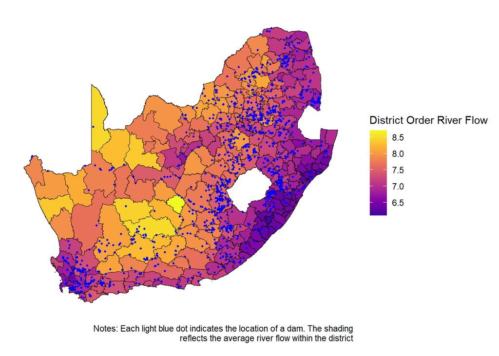

```r
sink(tempfile())

# Load the shapefile
shp_data <- st_read(file.path(path_data,"/p1/Country/gadm41_ZAF_3.shp"))

# Adding country districts
# Adding Dams
shp_dam_data <- st_read(file.path(path_data,"/p1/Dams/GDW_barriers_v1_0.shp"))

# Filter the sf object for South Africa
shp_dam_data_filtered <- shp_dam_data[shp_dam_data$COUNTRY == "South Africa", ]

# Adding River Gradients
shp_river_data <- st_read(file.path(path_data,"/p1/Rivers/HydroRIVERS_v10_af.shp"))

# Transform all layers to  WGS 84)
shp_data <- st_transform(shp_data, crs = 4326)
shp_dam_data_filtered <- st_transform(shp_dam_data_filtered, crs = 4326)
shp_river_data <- st_transform(shp_river_data, crs = 4326)

# Filter river data
# We couldn't find River Gradient data so we will be using river flow as a proxy
# Creating a bounding box to improve code speed (via filtering)
# Define the bounding box for South Africa
south_africa_bbox <- st_bbox(c(xmin = 16.45, ymin = -34.84, xmax = 32.89, ymax = -22.13), crs = 4326)

# Crop the river data using the bounding box
filtered_rivers <- st_crop(shp_river_data, south_africa_bbox)

# Simplify the geometry of filtered_rivers
# We simplify the geometry here in order to improve code speed
filtered_rivers_simplified <- st_simplify(filtered_rivers, dTolerance = 0.1)

# Perform spatial join with simplified rivers
shp_with_rivers <- st_join(shp_data, filtered_rivers_simplified, join = st_intersects)

# Calculate average ORD_FLOW grouped by NAME_3 (District Name)
average_ord_flow <- shp_with_rivers %>%
  st_drop_geometry() %>%  # Drop geometry to speed up summarization
  group_by(NAME_3) %>%
  summarize(avg_ord_flow = mean(ORD_FLOW, na.rm = TRUE))

# Merge the average ORD_FLOW back into shp_data
shp_data <- shp_data %>%
  left_join(average_ord_flow, by = "NAME_3")

sink()

# Note: Order flow data indicates the order of the rivers in term of their flows,
# meaning that lower values indicate that a river is classified as having more flow
# thus less order flow in our data = more river gradient (proxy).

##### Figure 1 plot ########

ggplot() +
  # Plot shp_data, filled by avg_ord_flow
  geom_sf(data = shp_data, aes(fill = avg_ord_flow), color = "black", size = 0.1) +
  # Plot dam data
  geom_sf(data = shp_dam_data_filtered, size = 0.7, color="blue", fill = "blue") +
  # Color scale for avg_ord_flow
  scale_fill_viridis_c(
    option = "plasma",
    begin = 0.1,
    na.value = "grey90") +

  # Add labels and theme
  labs(
    fill = "District Order River Flow",
    caption = "Notes: Each light blue dot indicates the location of a dam. The shading
    reflects the average river flow within the district"
  ) +
  theme_minimal()+
  theme(
    axis.title = element_blank(),    # Remove axis titles
    axis.text = element_blank(),     # Remove axis text (tick labels)
    axis.ticks = element_blank(),    # Remove axis ticks
    panel.grid = element_blank()     # Remove grid lines
  )
```

## Districts and electricity grid in Ethiopia

The map is composed of multiple layers of information within the Ethiopia region [@fried2021], the first of which is its administrative boundaries based on a level of detail 3. The second is population density data. These are joined in the common column ADM3_PCODE.

The third layer is Ethiopia’s main roads. The fourth layer is its power lines and the fifth is its enumerators by location provided by World Bank data.

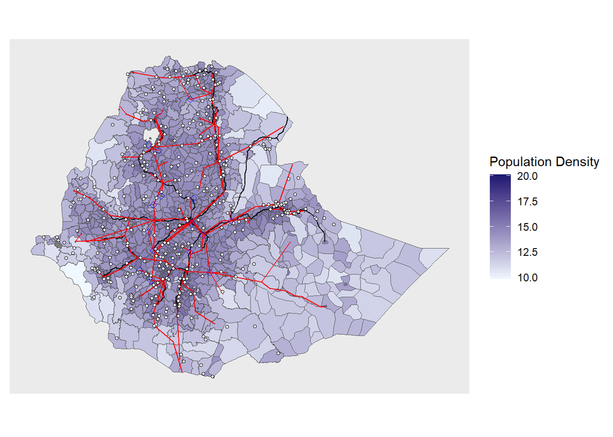

```r
sink(tempfile())

###Administrative boundaries
#Load ETH adm 3 shapefile:
sf.eth_admin_3 <- st_read(file.path(path_data,"/p2/adm_3/eth_admbnda_adm3_csa_bofedb_2021.shp"))

###Population Density
#Population density data (https://data.humdata.org/dataset/cod-ps-eth)
eth_pop <- read.csv(file.path(path_data,"/p2/pop_adm3_2022_v2.csv"))

#Joining
if (!("ADM3_PCODE" %in% colnames(eth_pop))) {
  eth_pop <- rename(eth_pop, ADM3_PCODE = admin3Pcode)
}

# Join the data on ADM3_PCODE:
joined_pop_geo <- left_join(sf.eth_admin_3, eth_pop, by = "ADM3_PCODE")


###Main Roads
#Road data
sf.roads <- st_read(file.path(path_data,"/p2/roads_2/Ethiopia_Roads.shp"))

# Convert the geometry column to an sf object
roads_geo <- st_as_sf(sf.roads, wkt = "geometry", crs = 4326)
roads_geo <- roads_geo %>% filter(LINKNO != "A5-5")


###Electricity lines
#Power lines data
sf.lines <- st_read(file.path(path_data,"/p2/electricity_grid/Ethiopia Electricity Transmission Network.shp"))

# Convert the geometry column to an sf object
lines_geo <- st_as_sf(sf.lines, wkt = "geometry", crs = 4326)


###Enumeration localities
#Enumerators Data (https://microdata.worldbank.org/index.php/catalog/2053/data-dictionary)
enum <- read.csv(file.path(path_data,"/p2/erss_survey/pub_eth_householdgeovariables_y1.csv"))

###Power Plants

#Power plants data (https://datacatalog.worldbank.org/search/dataset/0041714/Ethiopia-Power-Plants)
plants <- st_read(file.path(path_data,"/p2/eth_powerplants/ETH_PowerPlants.shp"))
plants_geo <- st_set_crs(plants, 4326)

#Adding Population Density Column
joined_pop_geo$pupulation_density <- log(joined_pop_geo$T_TL / joined_pop_geo$Shape_Area)

sink()

#Plotting:
ggplot() +
  geom_sf(data = joined_pop_geo, aes(fill = pupulation_density)) +  # Map the T_TL column to fill color
  scale_fill_gradient(low = "aliceblue", high = "midnightblue", name = "Population Density") +
  geom_sf(data = roads_geo, color = "black", size = 2) +
  geom_sf(data = lines_geo, color = "red", size = 0.5) +
  geom_point(data = enum, aes(x = LON_DD_MOD, y = LAT_DD_MOD), color = "black", fill = "white", size = 1, shape = 21) +
  geom_point(data = plants_geo, aes(x=LON, y=LAT), shape = 5, color = "blue") +
  theme(
    axis.text = element_blank(),
    axis.ticks = element_blank(),
    axis.title = element_blank(),
    panel.grid = element_blank()
  )
```

From [@pellegrina2021].

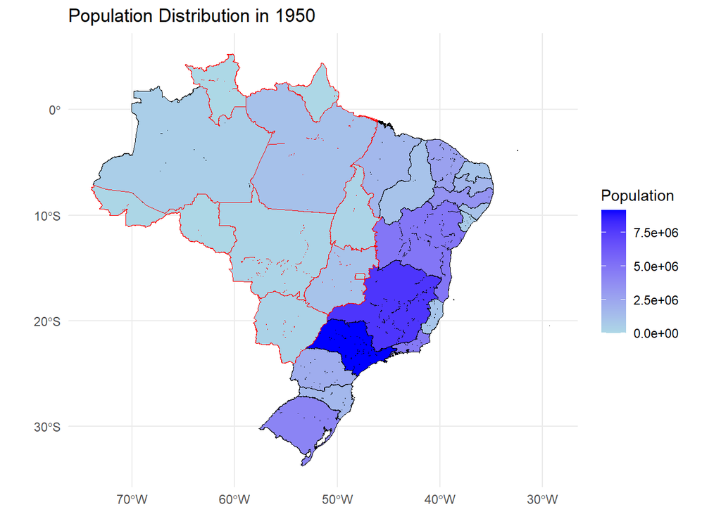

```r
sink(tempfile())

# Loading census data (ibge.gov.br)
df <- read_excel(file.path(path_data, "p3/census_data.xlsx"), sheet = 1)

# Renaming for consistency
df <- df %>%
  rename(name_state= Region)

# Loading Meso-Region boundaries
brazil_map <- read_meso_region(year = 2010)  # Most recent meso-region boundaries

# Aggregating meso-regions to the state level for simplicity
brazil_states <- brazil_map %>%
  group_by(name_state) %>%
  summarise(geom = st_union(geom)) %>%
  left_join(df, by = "name_state")  # Merge with population data

# Define North & Central-West states as "West"
west_states <- c("Amazonas", "Pará", "Acre", "Amapá", "Roraima", "Rondônia", "Tocantins",
                 "Mato Grosso", "Mato Grosso do Sul", "Goiás", "Distrito Federal")

# Extract only the "West" meso-regions (as done in paper)
west_map <- brazil_map %>%
  filter(name_state %in% west_states) %>%
  group_by(name_state) %>%
  summarise(geom = st_union(geom))

colnames(brazil_states)

sink()

#plotting maps
plot_map <- function(year) {
  ggplot() +
    geom_sf(data = brazil_states, aes(fill = .data[[year]]), color = "black") +
    geom_sf(data = west_map, fill = NA, color = "red", size = 1) +  # Red contour for "West"
    scale_fill_gradient(low = "lightblue", high = "blue", na.value = "white") +  # Light for low, dark for high
    labs(title = paste("Population Distribution in", year),
         fill = "Population") +
    theme_minimal()
}

print(plot_map("1950"))
```

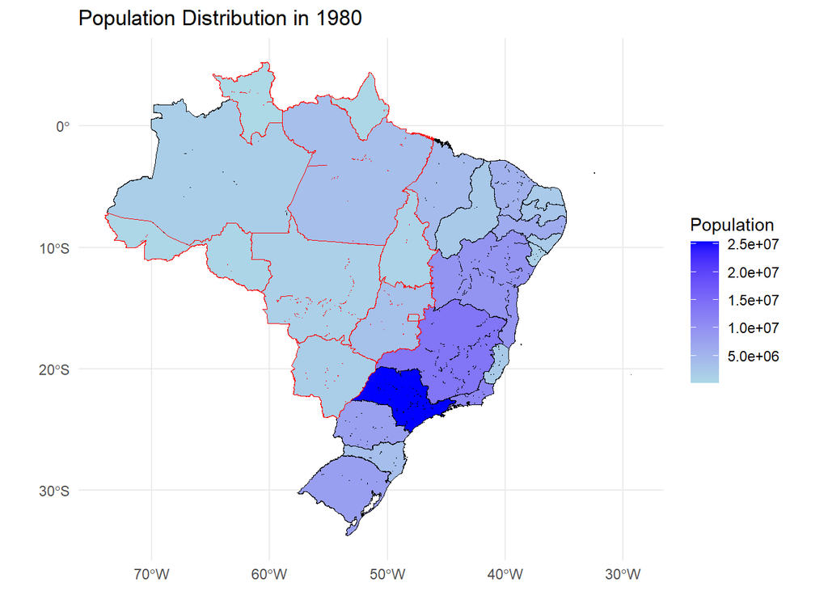

```r
print(plot_map("1980"))
```

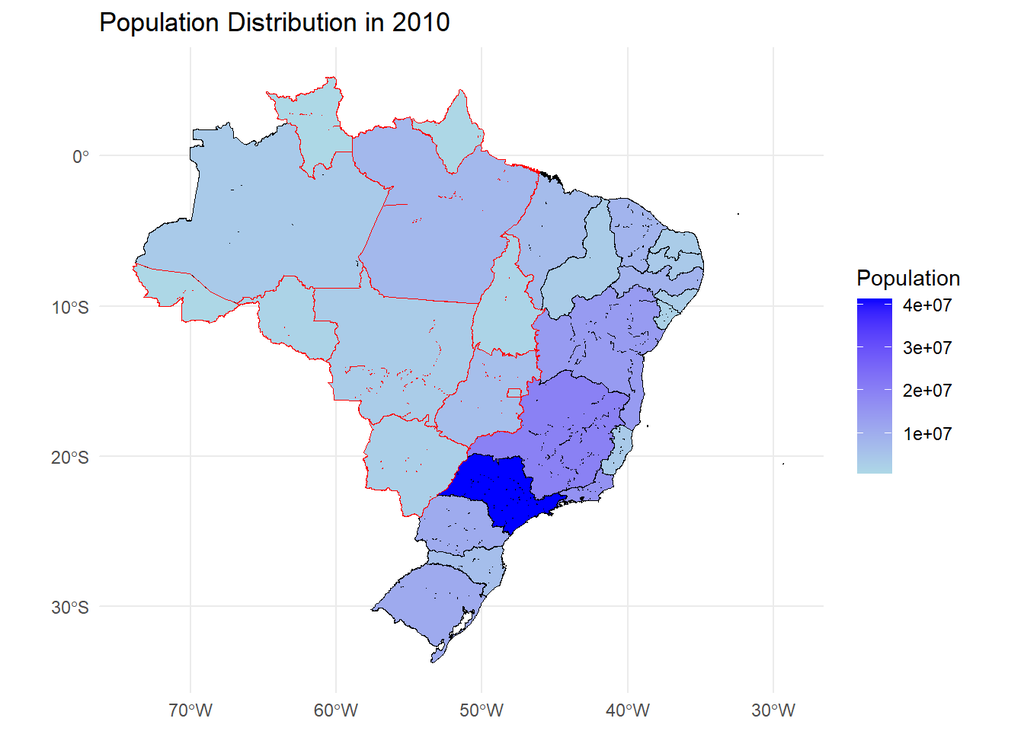

```r
print(plot_map("2010"))
```

## Vietnam’s road infrastructure by road type

From [@balboni2019].

In this paper, the authors manually georeferenced each map and traced the locations of roads by category, creating shapefiles that represent the road network for 2000 and 2010. While we were unable to manually reproduce these georeferences, we utilized a 2015 road dataset (referenced accordingly). In this dataset, we grouped the various road types and visualized them within Vietnam’s country shapefile.

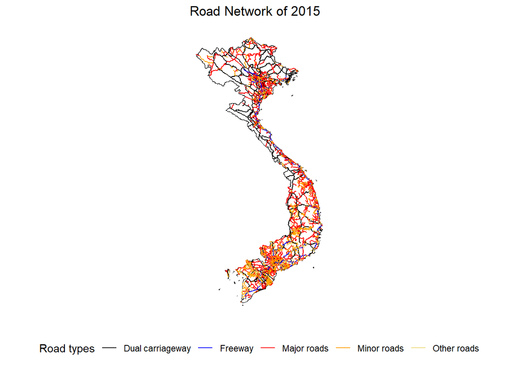

```r
sink(tempfile())

# Country shape data
# Read the shapefile
vietnam_country <- st_read(file.path(path_data,"p4/vietnam_country/gadm41_VNM_0.shp"))

# Road 2015 data

roads <- st_read(file.path(path_data, "p4/road network_2015/vnm_rdsl_2015_OSM.shp"))

# Counting the number of unique road types
unique_road_types <- unique(roads$type)

# Defining road type categories
# Reclassifing road types
roads <- roads %>%
  mutate(road_category = case_when(
    type %in% c("motorway", "motorway_link", "trunk", "trunk_link") ~ "Freeway",
    type %in% c("primary", "primary_link") ~ "Dual carriageway",
    type %in% c("secondary", "secondary_link", "tertiary", "tertiary_link") ~ "Major roads",
    type %in% c("residential", "unclassified", "service", "living_street", "pedestrian") ~ "Minor roads",
    type %in% c("footway", "path", "track", "cycleway", "steps", "proposed", "construction", "crossing", "services", "rest_area") ~ "Other roads",
    TRUE ~ "Other roads"  # Default for unknown categories
  ))

# Checking classification counts
table(roads$road_category)

sink()

road_colors <- c(
  "Freeway" = "blue",
  "Dual carriageway" = "black",
  "Major roads" = "red",
  "Minor roads" = "orange",
  "Other roads" = "lightgoldenrod"
)

# Plot
ggplot() +
  # Add the country shape
  geom_sf(data = vietnam_country, fill = NA, color = "black", size = 0.5) +
  # Add the road network
  geom_sf(data = roads, aes(color = road_category), size = 0.4, show.legend = TRUE) +
  # Customize colors for road categories
  scale_color_manual(values = road_colors) +
  # Add title and legend labels
  labs(title = "Road Network of 2015", color = "Road types") +
  # Apply a minimal theme
  theme_minimal() +
  # Customize legend and remove axis/grid
  theme(
    legend.position = "bottom",
    axis.text = element_blank(),
    axis.title = element_blank(),
    axis.ticks = element_blank(),
    panel.grid = element_blank(),
    panel.border = element_blank()
  )
```

## Brazil’s capital and main road infrastructure

The next figure is a map of the Brazilian road network indicating Brasilia and the 26 state capitals ([@morten2018]). It shows the highway network in 2000 separating radial highways from nonradial highways.

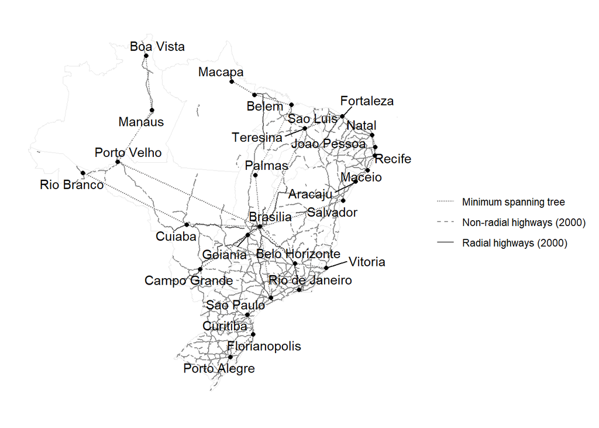

```r
sink(tempfile())

# Location of each state
states <- st_read(file.path(path_data,"p5/uf1940/uf1940_prj.shp"))
sf.states  <- rmapshaper::ms_simplify(states, keep=0.01, keep_shapes=TRUE)

# Information about roads
year  <- 2000
file_name = paste0(path_data, "/p5/roads/", year,"/highways_", year, "_prj.shp")
all_highways <- st_read(file_name)
sf.roads  <- rmapshaper::ms_simplify(all_highways, keep=0.01, keep_shapes=TRUE)

# Minimum spanning tree (mst_pie)
mst_pie <- st_read(file.path(path_data, "/p5/mst/mst_pie_prj.shp"))
sf.mst  <- rmapshaper::ms_simplify(mst_pie, keep=0.01, keep_shapes=TRUE)

# Cities in Brazil
capital_cities <- st_read(file.path(path_data,"/p5/cities/brazil_capital_cities_prj.shp"))
cities_xy <- cbind(capital_cities, st_coordinates(capital_cities))

sink()

#figure
ggplot() +
  geom_sf(data=sf.states, fill="white", color="grey90") +
  geom_sf(data=sf.mst, size=.8, linetype = "11", aes(color = "Minimum spanning tree"), show.legend = "line") +
  geom_sf(data=sf.roads %>% filter(dm_anlys_p == 1 & dm_radial == 0), size=.6, linetype = "dashed", aes(color = "Non-radial highways (2000)"), show.legend = "line") +
  geom_sf(data=sf.roads %>% filter(dm_anlys_p == 1 & dm_radial == 1), size=.9, aes(color = "Radial highways (2000)"), show.legend = "line") +
  theme_minimal() +
  theme(axis.title = element_blank(),
        axis.text = element_blank(),
        axis.ticks = element_blank(),
        panel.grid = element_blank()) +  # Removes grid and axis elements
  geom_point(data = cities_xy, aes(x = X, y = Y)) +
  geom_text_repel(data = cities_xy, aes(x = X, y = Y, label = CITY_NAME)) +
  labs(color = " ") +
  scale_color_manual(values = c("#777676", "#868686", "#565555"),
                     guide = guide_legend(override.aes = list(linetype = c("11", "dashed", "solid"))))
```

# Figure 1

Shape of Country with districts: https://gadm.org/download_country.html

Dam data: https://www.globaldamwatch.org/database

River Order Flow: https://www.hydrosheds.org/products/hydrorivers

# Figure 2

Shape of Country with districts: https://gadm.org/download_country.html

Roads: https://datacatalog.worldbank.org/search/dataset/0039933/Ethiopia-Roads

Population: https://data.humdata.org/dataset/cod-ps-eth

Electricity Grid: https://datacatalog.worldbank.org/search/dataset/0039311

Enumerators: https://microdata.worldbank.org/index.php/catalog/2053/data-dictionary

Power Plants: https://datacatalog.worldbank.org/search/dataset/0041714/Ethiopia-Power-Plants

# Figure 3

Census data: https://www.ibge.gov.br/en/statistics/social/population/18391-2010-population-census.html?edicao=19729&t=downloads

# Figure 4

Country Data: #https://gadm.org/download_country.html Road Network: https://data.humdata.org/dataset/viet-nam-roads

# Figure 5

https://www.openicpsr.org/openicpsr/project/183316/version/V1/view?path=/openicpsr/183316/fcr:versions/V1/Data/GIS_data&type=folder